What's The Progress?

# Using Matplotlib to Animate Data From a Velocity Recording

# Introduction

One of my friends approached me asking if I had any experience animating graphs, since I had experience with video editing. Though I had not had any formal experience, I decided that it would be a interesting challenge to embark.

I did some research and found a tutorial as seen in the section "Working Through Matplotlib Animation Tutorial"

# Demonstration

## Tracking a Line Through Time

[figure not shown]

## Plotting a Dot and Tracking Across Velocity Curve

[figure not shown]

## Generating The Gifs

To generate these gifs, I used [ffmpeg](https://ffmpeg.org/) to convert the mp4s to gifs.

To convert the mp4s to gifs, I opened my directory in the terminal and ran the following ffmpeg command, after converting the video to gif, I added and pushed the files to github. Since github does not show local embeds, I embedded the url of the gif from the github repository.

```
ffmpeg -i line_tracking_animated.mp4 line_tracking_animated.gif
```

Alternatively, if you have [ffmpeg](https://ffmpeg.org/) installed, you can run the following cell to run it in a jupyter cell

Breakdown of the command

- `ffmpeg` tells the terminal to use ffmpeg
- `-i` tells ffmpeg the input
- `line_tracking_animated.mp4` tells ffmpeg the source file
- `line_tracking_animated.gif` tells ffmpeg the output file title and format

```python
!ffmpeg -i line_tracking_animated.mp4 line_tracking_animated.gif
```

```python
!ffmpeg -i dot_tracking_animated.mp4 dot_tracking_animated.gif
```

# Importing Libraries + Loading Data

```python
from IPython.core.display import display, HTML
display(HTML("<style>.container { width:100% !important; }</style>"))
```

```python
import pandas as pd
import numpy as np
from matplotlib import pyplot as plt
from matplotlib import animation
from matplotlib.offsetbox import AnchoredText
```

```python
df = pd.read_csv("velocity.csv")
df
```

|  | Time (ms) | Velocity (m/s) |
| --- | --- | --- |
| 0 | 0 | 0.03 |
| 1 | 17 | 0.03 |
| 2 | 34 | 0.03 |
| 3 | 50 | 0.03 |
| 4 | 67 | 0.03 |
| ... | ... | ... |
| 1314 | 22167 | 0.89 |
| 1315 | 22183 | 0.89 |
| 1316 | 22200 | 0.41 |
| 1317 | 22217 | 0.41 |
| 1318 | 22233 | 0.41 |

1319 rows × 2 columns

```python
print("max time")
display(df["Time (ms)"].max())

print("min time")
display(df["Time (ms)"].min())

print("Velocity")
display(df["Velocity (m/s)"][1])

print("Max Velocity")
display(df["Velocity (m/s)"].max())

print("Final time")
display(df["Time (ms)"].iloc[-1]*60/1000)

print("Final time rounded")
display(int(round(df["Time (ms)"].iloc[-1]*60/1000, 1)))

print("column titles")
column_titles = list(df.columns.values)
display(column_titles)
```

```
max time
```

```
22233
```

```
min time
```

```
0
```

```
Velocity
```

```
0.03
```

```
Max Velocity
```

```
20.5
```

```
Final time
```

```
1333.98
```

```
Final time rounded
```

```
1334
```

```
column titles
```

```
['Time (ms)', 'Velocity (m/s)']
```

# Plotting Function

I wrote the `animateGraph` after modifying [Matplotlib Animation Tutorial](https://jakevdp.github.io/blog/2012/08/18/matplotlib-animation-tutorial/) to work for my velocity data from the `Having Line Plotted Through Time` section and later `Having a Dot Tracking Along the Velocity Curve`.

The function takes the general structure of the respective and makes it into a single function

## Explanation of Inputs

- `df` input `DataFrame`
- `x_column` column title for x axis
- `y_column` column title for y axis
- `dot_track` takes `yes` or `no`, if it is not `yes`, it will default to the line graph
- `framerate` integer that specifies the video's framerate

## Explanation of Variables

### Setting Up Data Section

- `x_df` `DataFrame` of just the x values, I seperated the x and y `DataFrames` to make it easier to follow in the animation function
- `y_df` `DataFrame` of just the x values, I seperated the x and y `DataFrames` to make it easier to follow in the animation function
- `x_max` maximum of the x values, used to set the bounds of x axis
- `y_max` maximum of the y values, used to set the bounds of y axis, added `2` to make space for the time and velocity printouts
- `last_index` used to prevent `Keyerror`, see `Figuring out Keyerror` section for a more in depth explanation

### Graph Type Settings Section

- `plot_dot` boolean used to decide which animation to use, if `True` will have animation output the dot tracker on graph
- `graph_type` string used to keep track of the animation, used for filename
  - can be either `dot_tracking` or `line_tracking`

### Animation Settings

- `time_seconds` takes last entry of x value to get the duration of the data converts from miliseconds to seconds, used later for `totalFrames` animation duration calculation
- `totalFrames` product of `framerate` and `time_seconds` to get the number of frames for matplotlib to animate

### Setting Up The Figure

- `fig` figure variable, stores figure object
  - the size was set to `(20,12)`
  - I followed the suggestions to change the size and output a sample file from [Stack Overflow How to Change Figure Size](https://stackoverflow.com/questions/332289/how-do-you-change-the-size-of-figures-drawn-with-matplotlib)
  - I followed the suggestions to change the font size from [Stack Overflow How to Change Font Size](https://stackoverflow.com/questions/3899980/how-to-change-the-font-size-on-a-matplotlib-plot)

### Setting Up Positions of X and Y Outputs For Value

- I followed the example set by the matplotlib wiki from [Text properties and layout](https://matplotlib.org/3.1.3/tutorials/text/text_props.html#sphx-glr-tutorials-text-text-props-py)
- `y_value_print` text object, will set the y value, for the demo, we use velocity set for `right` and `top` is updated frame by frame in the `animate(i)` function
- `x_value_print` text object, will set the x value, for the demo, we use time set for `left` and `top` is updated frame by frame in the `animate(i)` function

### Setting Up The Line Plot

- I used the `plot_dot` to determine which graph should be plotted
  - if `plot_dot` is `True`, we will plot the existing graph and have the dot
  - if `plot_dot` is `False`, we will plot the graph sections frame by frame
- To get the red dot, I read the instructions of the different passable arguments from the matplotlib wiki from [matplotlib.pyplot.plot](https://matplotlib.org/3.2.1/api/_as_gen/matplotlib.pyplot.plot.html#examples-using-matplotlib-pyplot-plot)

### Initialization Function: Plot The Background of Each Frame

- I kept the example set from the guide see `Working Through Matplotlib Animation Tutorial` for more details

### Animation Function. This Is Called Sequentially

- This section is broken up into two parts,
  1. Checking if the function reaches the last value of the `DataFrame`
  2. updating the x and y column print outs
- To check if the function has reached the last value of the `DataFrame`, we have a `if` conditional that checks if the `animate` function has reached the end of the `DataFrame`, if it does, then it will use the value at `last_index`, we want it to keep the last value to avoid the `Keyerror` as explained in the later experimental section
- Next, the function will set the `x_value` and `y_value` to be the final index value
  - `x_value` and `y_value` is used for animating the labels for the values of x and y
- Afterwards the function follow a second `if` statement, which will check if `plot_dot` is true or false
  - if `plot_dot` is `False`, the function will output everything up until the current `i` index value.
    - This is used for the animation that plots graph sections frame by frame
  - if `plot_dot` is `True`, the function will output the current `i` index value.
    - This is used for the animation that plots the point frame by frame
- The next section will update the x and y column print out values for each frame I took inspiration from [Matplotlib animations the easy way](https://brushingupscience.com/2016/06/21/matplotlib-animations-the-easy-way/) specifically the `"Changing labels and text"` section
  - `values_x` is a string variable that stores the x column title, adds colons, and the x value
  - `values_y` is a string variable that stores the y column title, adds colons, and the y value
  - After setting `values_x` and `values_y` we use `.set_text()` to update the `y_value_print` and `x_value_print` each time
- Once all the variables have been updated, `animate(i)` will return the `line` to the `animation.FuncAnimation()`, which will continue until it reaches the last frame

### Save The Animation as an mp4.

- I did not make significant changes to the original, I only changed the filename to match the graph type.
  - I wanted the filename to be the ' `x_column` vs `y_column` `graph_type` _animated.mp4'
  - The ideal file name would be 'Velocity_(m/s)_vs_Time (ms)_line_tracking_animated.mp4
    - When I tried parsing the `x_column` as a string, python had serious issues with the slash (/) part of (m/s), enough so that it would prevent the file from being saved
    - An potential alternative solution would to change m/s to m*s^-1, but it require changing the data or engineering a solution that read the units and replaced slashes with* unit^-1. After evaluating the alternatives, I realized it would be easier to rename the file. If this function were used to generate hundreds of graphs from hundreds of source files, I would need to find a better solution. Since the purpose of this function is to make it easier to change between the dot and line tracking, I did not invest any further time into developing an alternative solution

```python
def animateGraph(df,x_column, y_column, dot_track, framerate):
# Setting up data
    x_df = df[x_column]
    y_df = df[y_column]
    x_max = int(np.ceil(df[x_column].max()))
    y_max = int(np.ceil(df[y_column].max())) + 2
    last_index = len(df)-1

# Check if we are plotting the graph or a graph + dot
    if(dot_track.lower() == "yes"):
        plot_dot = True
        graph_type = "dot_tracking"
    else:
        plot_dot = False
        graph_type = "line_tracking"

# Animation settings
    time_seconds = x_df.iloc[-1]/1000
    totalFrames = int(round(framerate * time_seconds))

# Setting up the figure
    fig = plt.figure()
    fig.set_size_inches(20, 12)
    fig.savefig('test2png.png', dpi=100)
    plt.rcParams.update({'font.size': 24})

# Setting up the axes
    ax = plt.axes(xlim=(0, x_max), ylim=(0, y_max))
    ax.set(title= x_column + ' vs ' + y_column,
           ylabel= y_column,
           xlabel= x_column,
           )
# Setting up the positions of velocity and time outputs
    left, width = .1, .75
    bottom, height = .25, .73
    right = left + width
    top = bottom + height

    y_value_print = ax.text(right, top, "y value",
                             horizontalalignment='right',
                             verticalalignment='top',
                             transform=ax.transAxes)

    x_value_print = ax.text(left, top, "x value",
                             horizontalalignment='left',
                             verticalalignment='top',
                             transform=ax.transAxes)

# Setting up the line plot
    if(plot_dot == True):
        plt.plot(x_df, y_df)
        line, = plt.plot([], [], linestyle='none', marker = 'o', ms = 10, color='r')
    else:
        line, = plt.plot(x_df, y_df)

# initialization function: plot the background of each frame
    def init():
        line.set_data([], [])
        return line,

# animation function. This is called sequentially
    def animate(i):
        if(i > last_index):
            x_value = x_df[last_index]
            y_value = y_df[last_index]

            if(plot_dot == False):
                x = x_df[0:last_index]
                y = y_df[0:last_index]
            else:
                x = x_df[last_index]
                y = y_df[last_index]
        else:
            x_value = x_df[i]
            y_value = y_df[i]

            if(plot_dot == False):
                x = x_df[0:i]
                y = y_df[0:i]
            else:
                x = x_df[i]
                y = y_df[i]
        line.set_data(x, y)

    # Update the figure with x and y values
        values_x = x_column + ": " + str(x_value)
        values_y = y_column + ": " + str(y_value)
        y_value_print.set_text(values_y)
        x_value_print.set_text(values_x)
        return line,

# call the animator.  blit=True means only re-draw the parts that have changed.
    anim = animation.FuncAnimation(fig, animate, init_func=init,frames = totalFrames, interval=0, blit=False)

# save the animation as an mp4.  This requires ffmpeg or mencoder to be
# installed.  The extra_args ensure that the x264 codec is used, so that
# the video can be embedded in html5.  You may need to adjust this for
# your system: for more information, see
# http://matplotlib.sourceforge.net/api/animation_api.html
    anim.save(graph_type + '_animated.mp4', fps=framerate, extra_args=['-vcodec', 'libx264'])

plt.show()
```

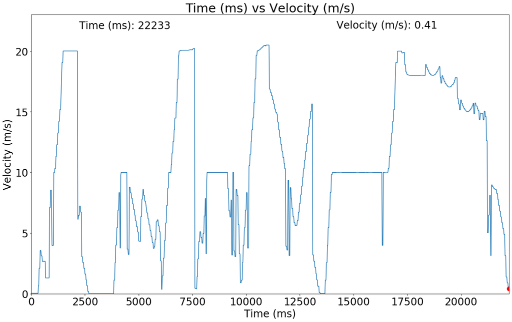

```python
animateGraph(df,"Time (ms)", "Velocity (m/s)", "yes", 60)
```

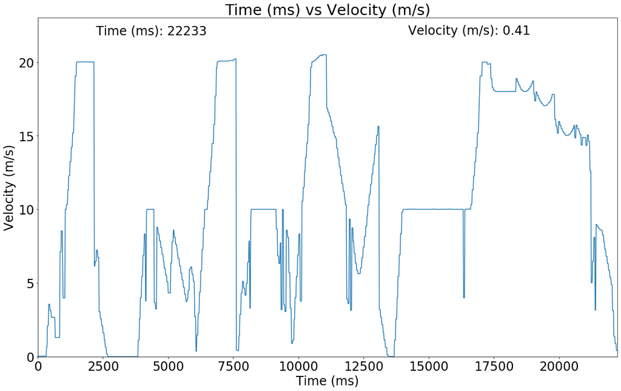

```python
animateGraph(df,"Time (ms)", "Velocity (m/s)", "no", 60)
```

# Working Through [Matplotlib Animation Tutorial](https://jakevdp.github.io/blog/2012/08/18/matplotlib-animation-tutorial/)

I used Jake Vanderplas's sine wave example posted below as a base to understand how matplotlib animates. I modified it to make it work with the velocity and time data I was given from my friend.

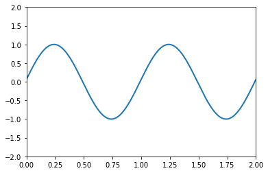

```python
"""
Matplotlib Animation Example

author: Jake Vanderplas
email: vanderplas@astro.washington.edu
website: http://jakevdp.github.com
license: BSD
Please feel free to use and modify this, but keep the above information. Thanks!
"""

import numpy as np
from matplotlib import pyplot as plt
from matplotlib import animation

# First set up the figure, the axis, and the plot element we want to animate
fig = plt.figure()
ax = plt.axes(xlim=(0, 2), ylim=(-2, 2))
line, = ax.plot([], [], lw=2)

# initialization function: plot the background of each frame
def init():
    line.set_data([], [])
    return line,

# animation function.  This is called sequentially
def animate(i):
    x = np.linspace(0, 2, 1000)
    y = np.sin(2 * np.pi * (x - 0.01 * i))
    line.set_data(x, y)
    return line,

# call the animator.  blit=True means only re-draw the parts that have changed.
anim = animation.FuncAnimation(fig, animate, init_func=init,
                               frames=200, interval=20, blit=True)

# save the animation as an mp4.  This requires ffmpeg or mencoder to be
# installed.  The extra_args ensure that the x264 codec is used, so that
# the video can be embedded in html5.  You may need to adjust this for
# your system: for more information, see
# http://matplotlib.sourceforge.net/api/animation_api.html
anim.save('basic_animation.mp4', fps=30, extra_args=['-vcodec', 'libx264'])

plt.show()
```

## Having Line Plotted Through Time

[output not shown]

[output cut: 1279 more lines]

[output not shown]

[figure not shown]

```python
x_df = df["Time (ms)"]
y_df = df["Velocity"]
x_max = int(np.ceil(df["Time (ms)"].max()))
y_max = int(np.ceil(df["Velocity"].max()))

time_seconds = x_df.iloc[-1]/1000
framerate = 60
totalFrames = int(round(framerate * time_seconds))

# First set up the figure, the axis, and the plot element we want to animate
fig = plt.figure()
fig.set_size_inches(18.5, 10.5)
fig.savefig('test2png.png', dpi=100)

# transparency settings for the figure
#fig.patch.set_alpha(0.)

ax = plt.axes(xlim=(0, x_max), ylim=(0, y_max))
ax.set(title='Velocity vs Time',
           ylabel="Velocity",
           xlabel="Time (ms)")

line, = plt.plot(x_df, y_df)

# initialization function: plot the background of each frame
def init():
    line.set_data([], [])
    return line,

# animation function.  This is called sequentially
def animate(i):
    x = x_df[0:i]
    print("i", i)
    y = y_df[0:i]
    line.set_data(x, y)
    return line,

# call the animator.  blit=True means only re-draw the parts that have changed.
anim = animation.FuncAnimation(fig, animate, init_func=init,frames = totalFrames, interval=0, blit=False)

# save the animation as an mp4.  This requires ffmpeg or mencoder to be
# installed.  The extra_args ensure that the x264 codec is used, so that
# the video can be embedded in html5.  You may need to adjust this for
# your system: for more information, see
# http://matplotlib.sourceforge.net/api/animation_api.html
anim.save('basic_animation.mp4', fps=framerate, extra_args=['-vcodec', 'libx264'])

plt.show()
```

### Learning How Matplotlib plots

In the following cells, I experimented with the ranges for which data to be plotted. Once I figured out putting `start:end` into a dataframe, I used this for the first function

With an understanding of this property I was able to have the graph from `0` to the value at the specific frame.

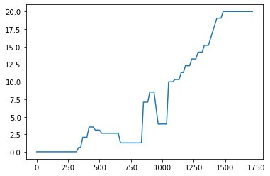

```python
plt.plot(x_df[0:100], y_df[0:100])
plt.show()
```

### Messing with labels

Although not shown here, I later found <a href = https://brushingupscience.com/2016/06/21/matplotlib-animations-the-easy-way/> a very helpful guide that demonstrated animating text and labels </a>. I did not know that I could incoorperate text changes in the `animate` fucntion with on matplotlib. I implemented most of the changes of `set_text()` and `ax.text()` in the `animateGraph()` section. It was easier to modify `animateGraph()` as I could run it to get a output and would not have the same code in 3 other places of the notebook.

Another goal of this section was to experiment with matplotlib to get the outputs to my liking. I learned <a href =https://stackoverflow.com/questions/332289/how-do-you-change-the-size-of-figures-drawn-with-matplotlib> I could change the graph size with</a> `fig.set_size_inches()`

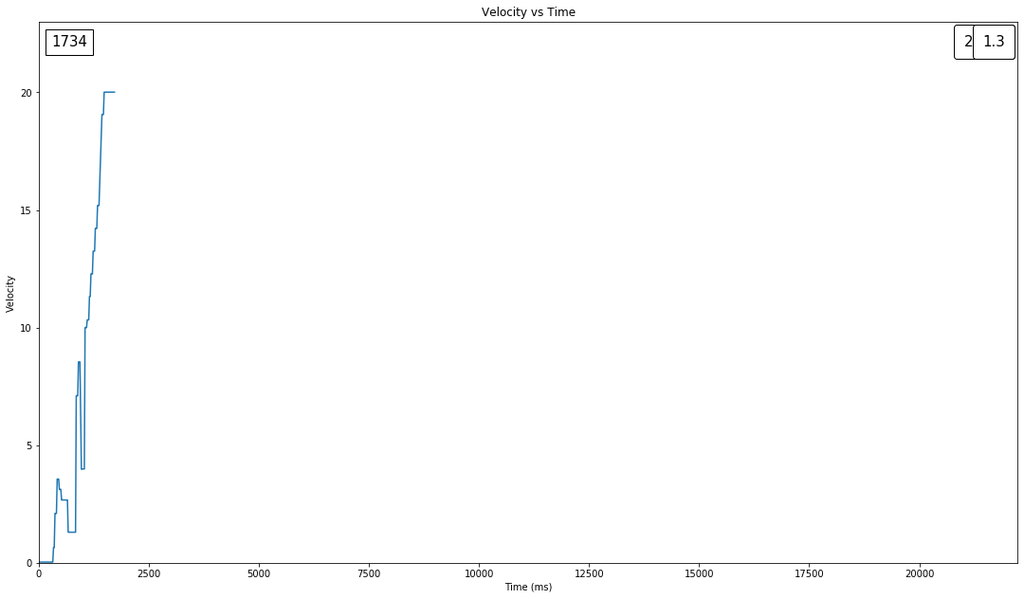

```python
fig = plt.figure()
fig.set_size_inches(18.5, 10.5)
fig.savefig('test2png.png', dpi=100)

ax = plt.axes(xlim=(0, x_max), ylim=(0, y_max+2))
ax.set(title='Velocity vs Time',
           ylabel="Velocity",
           xlabel="Time (ms)")

at1 = AnchoredText(x_df[100],
    prop=dict(size=15), frameon=True,
    loc='upper left',
    )
at.patch.set_boxstyle("round,pad=0.3,rounding_size=0.5")
ax.add_artist(at1)

at2 = AnchoredText(y_df[100],
    prop=dict(size=15), frameon=True,
    loc='upper right',
    )
at2.patch.set_boxstyle("round,pad=0.3,rounding_size=0.2")
ax.add_artist(at2)

at3 = AnchoredText(1.3,
    prop=dict(size=15), frameon=True,
    loc='upper right',
    )
at3.patch.set_boxstyle("round,pad=0.3,rounding_size=0.2")
ax.add_artist(at3)

plt.plot(x_df[0:100], y_df[0:100])
plt.show()
```

### print statements

I used these print statements to figure out why my maxes were not being rounded to the nearest whole number.

Initially, I tried using `round( #number, #decimal places)`, [from Stackoverflow](https://stackoverflow.com/questions/31818050/round-number-to-nearest-integer) but the native function concatenated for values such as `20.5` to `20` instead of `21`

Eventually I found a detailed explanation behind the native python `round()` function [from RealPython](https://realpython.com/python-rounding/), in addition to suggested alternative functions and libraries I could use that would solve the issue I was running into. The suggestion was to use `ceil` from the `math` libraries. I ended up using `ceil` from the `numpy` libraries since I didn't want to import another library

```python
print("y_max:", df["Time (ms)"].max())
print()

print("y_max ceil rounding:", np.ceil(df["Time (ms)"].max()))
print()

print("x_max:", df["Velocity"].max())
print()

print("x_max ceil rounding:", np.ceil(df["Velocity"].max()))
print()

print("issue rounded y_max (Time):", int(round(df["Time (ms)"].max(),1)))
print()


print("issue rounded x_max (Velocity):", int(round(df["Velocity"].max(),1)))
print()
```

[output not shown]

## Having a Dot Tracking Along the Velocity Curve

After making my modifications, I copied my modified version and further adjusted it further titled `Having a Dot Tracking Along the Velocity Curve` to print the plot first and have a single point track along the plotted graph

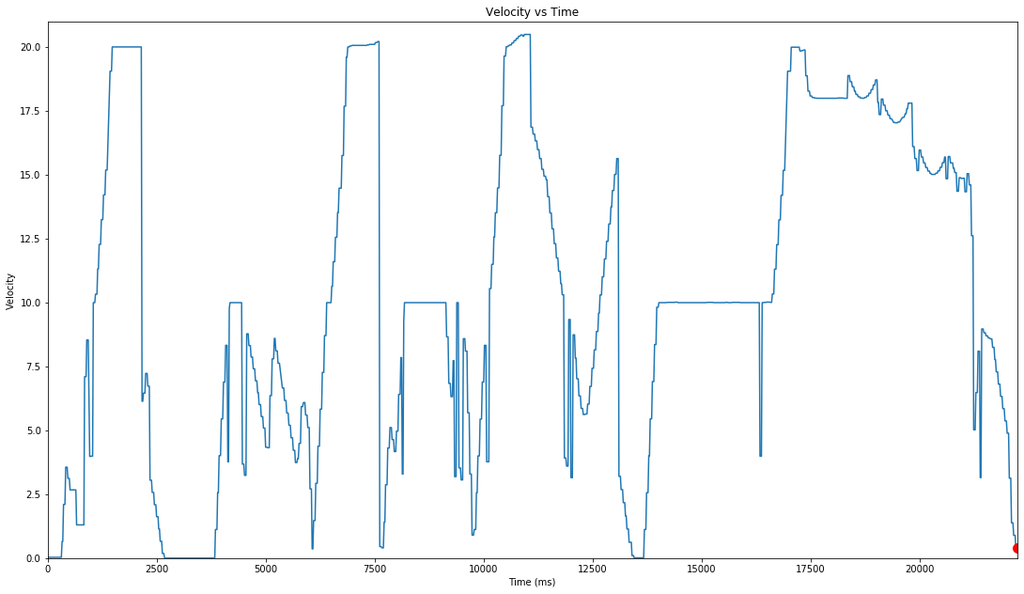

```python
x_df = df["Time (ms)"]
y_df = df["Velocity (m/s)"]
x_max = int(np.ceil(df["Time (ms)"].max()))
y_max = int(np.ceil(df["Velocity (m/s)"].max()))

time_seconds = x_df.iloc[-1]/1000
framerate = 60
totalFrames = len(df)

# First set up the figure, the axis, and the plot element we want to animate
fig = plt.figure()
fig.set_size_inches(18.5, 10.5)
fig.savefig('test2png.png', dpi=100)

# transparency settings for the figure
#fig.patch.set_alpha(0.)

ax = plt.axes(xlim=(0, x_max), ylim=(0, y_max))
ax.set(title='Velocity vs Time',
           ylabel="Velocity",
           xlabel="Time (ms)")

# transparency settings for the plot area
#ax.patch.set_facecolor('#ababab')
#ax.patch.set_alpha(0)

plt.plot(x_df, y_df)
line, = plt.plot([], [], linestyle='none', marker = 'o', ms = 10, color='r')

# initialization function: plot the background of each frame
def init():
    line.set_data([], [])
    return line,

# animation function.  This is called sequentially
def animate(i):
    x = x_df[i]
    #print("x")
    #print(x)
    y = y_df[i]
    line.set_data(x, y)
    return line,

# call the animator.  blit=True means only re-draw the parts that have changed.
anim = animation.FuncAnimation(fig, animate, init_func=init,frames = totalFrames, interval=0, blit=True)

# save the animation as an mp4.  This requires ffmpeg or mencoder to be
# installed.  The extra_args ensure that the x264 codec is used, so that
# the video can be embedded in html5.  You may need to adjust this for
# your system: for more information, see
# http://matplotlib.sourceforge.net/api/animation_api.html
anim.save('dot_tracking_animation_test.mp4', fps=framerate, extra_args=['-vcodec', 'libx264'])

plt.show()
```

## Figuring out `Keyerror`

While running `Dot Tracking Along the Velocity Curve` I got a consistent `keyerror` when plotting i. The following code blocks helped me debug the values of i for each iteration.

I later realized that the `keyerror` was caused by my totalFrames calculation, which took the last value of the data (milliseconds converted to seconds), multiplied it by the framerate, and was rounded to get total number of frames. Before changing to use the length of the dataframe, the `totalFrames` was `1333.98`, which was rounded to 1334. The `keyerror` occured because `animate(i)` uses the `frames` variable as a index. Once animate reached the length of the dataframe (`1319`) the animation stopped, but in the `animation.FuncAnimation()` function continued to pass values in for `i`. When computing for `x`, this caused a `keyerror` since `animation.FuncAnimation()` would continue to feed values in for `i`, but in the dataframe no such values existed.

To prevent this from happening, I added a conditional that when we reached the end of the dataframe, we would use the last value of the dataframe.

```python
x_df = df["Time (ms)"]
y_df = df["Velocity (m/s)"]

for i in x_df:
    x = x_df[i]
    #print("i = ",i,",", "a = ",a)
    y = y_df[i]
    print("i = ", i, "x = ", x, ",", "y = ",y)
    print()
```

```
i =  0 x =  0 , y =  0.03

i =  17 x =  284 , y =  0.03

i =  34 x =  567 , y =  2.67

i =  50 x =  834 , y =  1.3

i =  67 x =  1134 , y =  10.33

i =  84 x =  1467 , y =  19.06

i =  100 x =  1734 , y =  20.01

i =  117 x =  2017 , y =  20.01

i =  134 x =  2300 , y =  6.73

i =  150 x =  2567 , y =  1.14

i =  167 x =  2850 , y =  0.0

i =  184 x =  3134 , y =  0.0

i =  200 x =  3400 , y =  0.0

i =  217 x =  3684 , y =  0.0

i =  234 x =  3967 , y =  4.01

i =  250 x =  4234 , y =  10.0

i =  267 x =  4517 , y =  3.24

i =  284 x =  4800 , y =  6.94

i =  300 x =  5067 , y =  4.32

i =  317 x =  5400 , y =  6.66

```

[output cut: 102 more lines]

```
i =  1200 x =  20267 , y =  15.02

i =  1217 x =  20550 , y =  15.48

i =  1234 x =  20833 , y =  15.09

i =  1250 x =  21100 , y =  15.05

i =  1267 x =  21383 , y =  3.15

i =  1284 x =  21667 , y =  8.25

i =  1300 x =  21933 , y =  5.85

i =  1317 x =  22217 , y =  0.41
```

```
---------------------------------------------------------------------------
KeyError                                  Traceback (most recent call last)
<ipython-input-9-9d1447f8ceb4> in <module>
      3
      4 for i in x_df:
----> 5     x = x_df[i]
      6     #print("i = ",i,",", "a = ",a)
      7     y = y_df[i]

~/miniconda3/lib/python3.7/site-packages/pandas/core/series.py in __getitem__(self, key)
   1069         key = com.apply_if_callable(key, self)
   1070         try:
-> 1071             result = self.index.get_value(self, key)
   1072
   1073             if not is_scalar(result):

~/miniconda3/lib/python3.7/site-packages/pandas/core/indexes/base.py in get_value(self, series, key)
   4728         k = self._convert_scalar_indexer(k, kind="getitem")
   4729         try:
-> 4730             return self._engine.get_value(s, k, tz=getattr(series.dtype, "tz", None))
   4731         except KeyError as e1:
   4732             if len(self) > 0 and (self.holds_integer() or self.is_boolean()):

pandas/_libs/index.pyx in pandas._libs.index.IndexEngine.get_value()

pandas/_libs/index.pyx in pandas._libs.index.IndexEngine.get_value()

pandas/_libs/index.pyx in pandas._libs.index.IndexEngine.get_loc()

pandas/_libs/hashtable_class_helper.pxi in pandas._libs.hashtable.Int64HashTable.get_item()

pandas/_libs/hashtable_class_helper.pxi in pandas._libs.hashtable.Int64HashTable.get_item()

KeyError: 1334
```

```python
df.iloc[1318]
#len(df)
```

```
Time (ms)    22233.00
Velocity         0.41
Name: 1318, dtype: float64
```

```python
display(x_df)
```

```python
display(framerate * time_seconds)
totalFrames
```

```
1333.98
```

```
1334
```

# Messing with a overlapping graph

while looking for solutions to animate the velocity and time outputs, I stumbled upon a method to use subplots. If I come back to this project, I would want to make a line tracing option, where a line plot is generated, and another plot will overlap

```python
fig = plt.figure()
fig.set_size_inches(18.5, 10.5)
fig.savefig('test2png.png', dpi=100)

fig, ax = plt.subplots()
ax.plot(x_df, y_df)
plt.plot(x_df[0:100], y_df[0:100])

plt.show()
```

```python
!jupyter nbconvert  Animating-Velocity-Graph.ipynb --to html
```

```
[NbConvertApp] Converting notebook Animating-Velocity-Graph.ipynb to html
[NbConvertApp] Writing 812059 bytes to Animating-Velocity-Graph.html
```